# Modeling and prediction for movies

### After the determination of the model, I would like to check the conditions of the Multiple linear regression. The conditions include:

1. linear relationship between (numerical) explanatory variable and response variable
2. nearly normal residuals with mean 0
3. constant variability of residuals
4. independent residuals

Next, I will check the conditions one by one.

#### Firstly, check the linear relationships between the two numerical explanatory varaibles (runtime and critics_score) and the response variable.

From Figure 4 and Figure 6 along with the correlation values R respectively, the response variable audience_score has a weak lienar relationship with the explanatory variable runtime (R=0.18), but has a strong linear relationship with the explanatory variable critics_score (R=0.7).

I will also use residuals plots to check the linearity relationships.

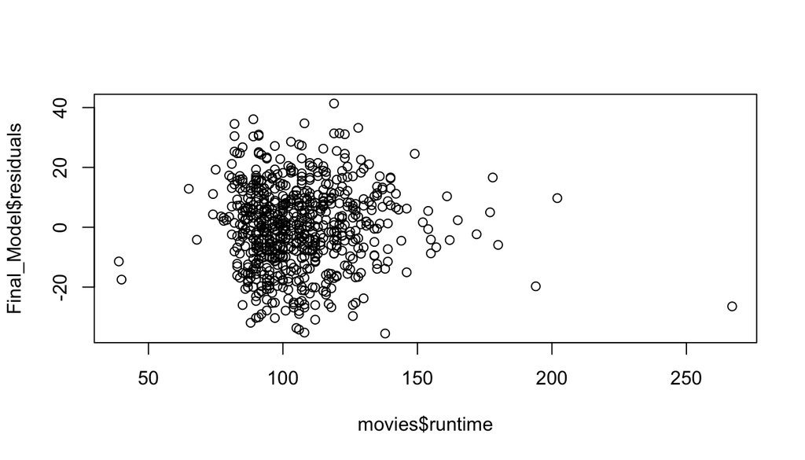

```r
#1. check the 1st condition: linearlity using residuals plots with residuals VS runtime
Final_Model <- lm(audience_score ~ genre + runtime + critics_score +
                   best_pic_nom + best_actress_win, data=movies)
plot(Final_Model$residuals ~ movies$runtime)
```

From the plot of residuals vS runtime, the residuals are randomly scattered around 0.

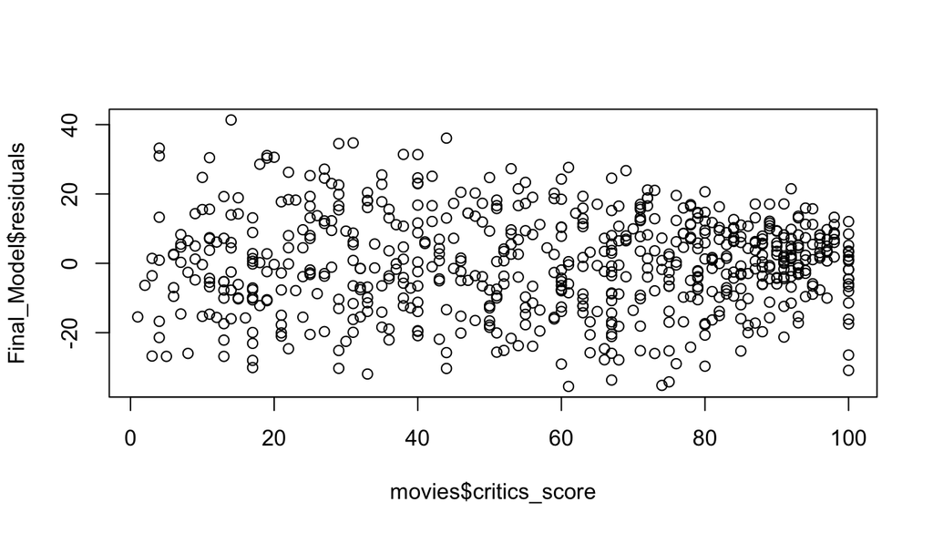

```r
#1. check the 1st condition: linearlity using residuals plots with residuals VS critics_score
Final_Model <- lm(audience_score ~ genre + runtime + critics_score +
                   best_pic_nom + best_actress_win, data=movies)
plot(Final_Model$residuals ~ movies$critics_score)
```

From the plot of residuals vS critics_score, the residuals are randomly scattered around 0.

Thus, we meet the first condition here.

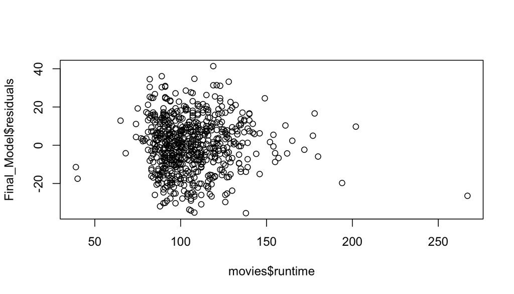

```r
#1. check the 1st condition: linearlity using residuals plots with residuals VS runtime
Final_Model <- lm(audience_score ~ genre + runtime + critics_score +
                   best_pic_nom + best_actress_win, data=movies)
plot(Final_Model$residuals ~ movies$runtime)
```

#### Secondly, check the normality of the residuals.

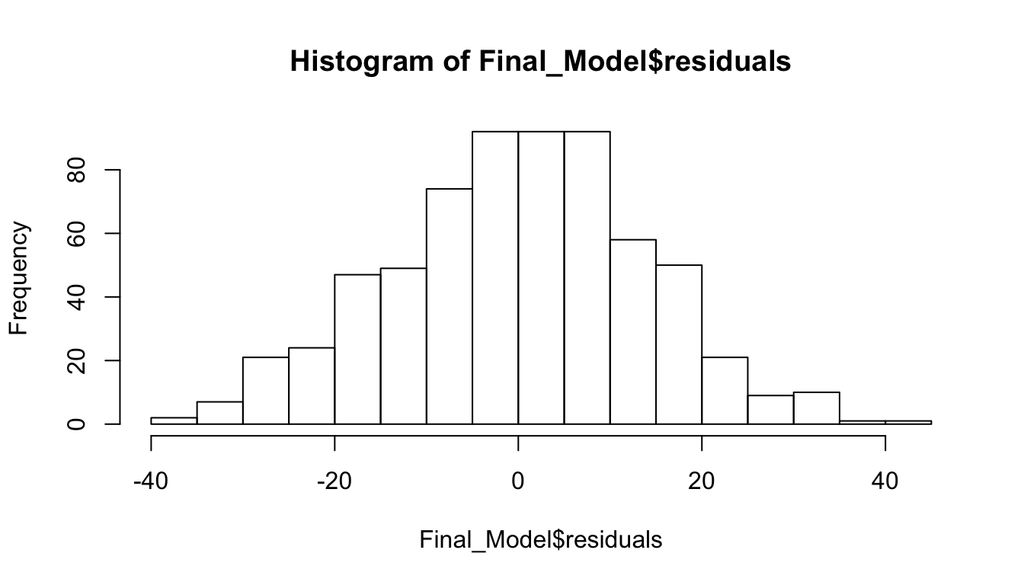

```r
#2. check the 2nd condition: nearly normal residuals with mean 0
hist(Final_Model$residuals)
```

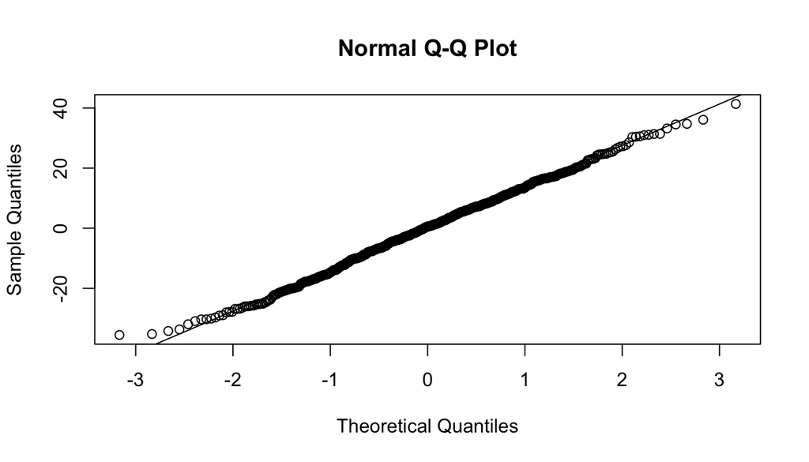

```r
qqnorm(Final_Model$residuals)
qqline(Final_Model$residuals)
```

From the histogram, we can view a quite good normal distribution. From the Q-Q plot, except some points at the tails, we don’t see any huge deviations from the mean. So we can say this condition seems to be fairly satisfied.

#### Thirdly, check the constant variability of the residuals

the residuals should be equally varaible for low and high values of the predicted response varaible.

I will check the residuals plots of residuals VS predicted values.

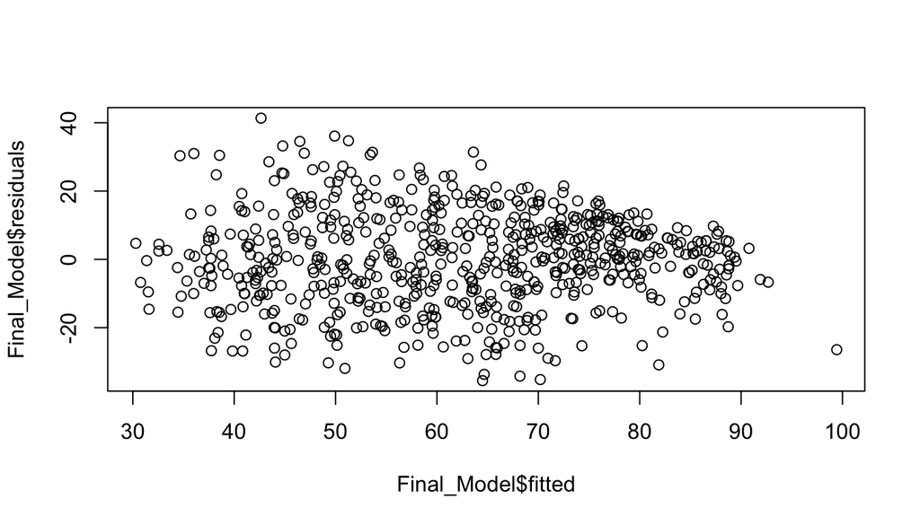

```r
#3. check the 3rd condition: constant variability of residuals
plot(Final_Model$residuals ~ Final_Model$fitted)
```

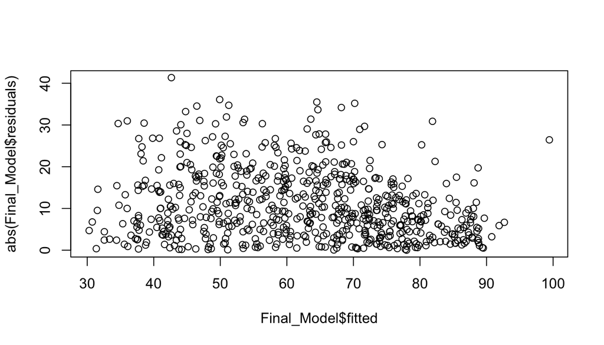

```r
plot(abs(Final_Model$residuals) ~ Final_Model$fitted)
```

The first plot above is the residuals VS the fitted. We can see a little bit fan shape, but not bad. It appears that the variability of the residuals stay constant as the values of the predicted values change. So the constant variability condition appears to be met.

The second plot above is the absolute values of residuals VS the fitted. So if we would see a fan shape in the first plot, we would see a triangle in the absoute residuals VS fitted plot.

#### Fourthly, check the independence of the residuals

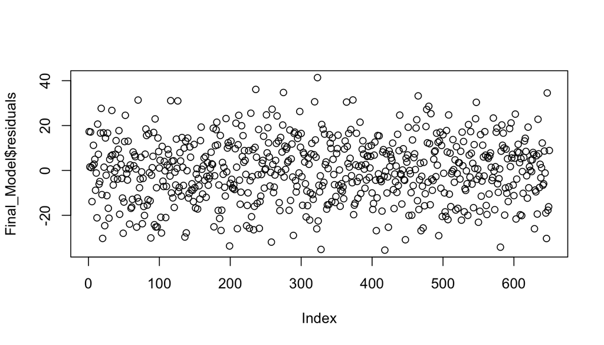

```r
#4. check the 4th condition: independent residuals
plot(Final_Model$residuals)
```

From the plot above, we take a look to see if the order of data collection plot looks wonky in any way. If there was come non-independent structure, we would see these residuals increasing or decreasing, but we don’t see any such pattern. So the condition of independent residuals is met.

To conclude, all the conditions for the multiple linear regression are met. And based on the backword method, the final model is parsimonious based on the variables discussed in this study.

## Part 5: Prediction

Based on the final model equation:

Predicted audience_score = 29.17 + 6.06 GenreAnimation + 5.98558 genreArt House & International - 0.50511 genreComedy +9.85007 genreDocumentar + 1.81989 genreDrama - 8.35275 genreHorror + 10.26484 genreMusical & Performing Arts - 4.10073 genreMystery & Suspense + 1.24587 genreOther - 6.49455 genreScience Fiction & Fantasy + 0.06146 runtime + 0.44005 critics_score + 9.36084 best_pic_nomyes - 2.27080 best_actress_winyes

I am interested to know the audience_score for a movie with the following characteristics, genre = Comedy, runtime = 120 minutes, critics_score = 90, best_pic_nom = yes, and best_actress_win = yes

```r
new_audience_score <- data.frame(genre = "Comedy", runtime = 120, critics_score = 90, best_pic_nom = "yes", best_actress_win = "yes")
predict(Final_Model,new_audience_score)
```

```
##        1
## 82.73827
```

Thus, the predicted audience_score for the above characterisitcs is 82.738.

I can also construct a prediction interval around this prediction, which will provide a measure of uncertainty around the prediction.

```r
predict(Final_Model,new_audience_score, interval = "prediction", level = 0.05)
```

```
##        fit      lwr      upr
## 1 82.73827 81.83874 83.63779
```

## Part 6: Conclusion

Predicted audience_score = 29.17 + 6.06 GenreAnimation + 5.98558 genreArt House & International - 0.50511 genreComedy +9.85007 genreDocumentar + 1.81989 genreDrama - 8.35275 genreHorror + 10.26484 genreMusical & Performing Arts - 4.10073 genreMystery & Suspense + 1.24587 genreOther - 6.49455 genreScience Fiction & Fantasy + 0.06146 runtime + 0.44005 critics_score + 9.36084 best_pic_nomyes - 2.27080 best_actress_winyes

It means that when keep all other variables constant, the movies when gene = Musical & Performing Arts are most popular among audience, while the movies when gene = Horror are least popular among audience.

Referring to runtime, as the runtime increases by one minute, while keep all other variables constant, the audience_score will increase by 0.06, on average, which are only valid within the range of the runtime.

Referring to scitics_score, as the scritics_score increases by one unit, while keep all other variables constant, the audience_score will increase by 0.44, on average.

Referring to Best_pic_nom, when keep all other variables constant, the audience_scores for the movies which were nominated as best_pic is 9.36 units higher on average than those movies which were not nominated as best_pic.

However, referring to the best_actress_win, when keep all other variables constant, the audience_scores for the movies whose main actress won the Oscar were 2.27 units lower on average than those movies whose main actress didn’t won the Oscar.